# Tvyal Newsletter

Aghasi Tavadyan

2024-02-16

*English summary below.*

Հարգելի գործընկեր,

Հուսով եմ լավ եք: Ներկայացնում եմ այս շաբաթվա վերլուծությունները և աշխատանքները.

## 📈📉❓ Արտահանման 55.3 տոկոս աճ թե՞ -12.2 տոկոս անկում

### Կառուցվածքային փոփոխությունները Հայաստանի առևտրաշրջանառության մեջ

Վերջի երկու տարիների ընթացքում Հայաստանի առևտրաշրջանառության կառուցվածքը գրանցել է զգալի փոփոխություններ։ 2023 թվականին արտահանումը աճել է զգալի 55,3 տոկոսով՝ 5,4 միլիարդ դոլարից (2022) հասնելով 8,4 միլիարդ դոլարի։ Միաժամանակ ներմուծումն աճել է 40,2 տոկոսով՝ նույն ժամանակահատվածում 8,8 միլիարդ դոլարից հասնելով 12,3 միլիարդ դոլարի: Վերջին երկու տարիների ընթացքում արտահանումը և ներմուծումը աճել են համապատասխանաբար 2,8 և 2,3 անգամ։ Առկա են նաև զգալի կառուցվածքային փոփոխություններ առևտրաշրջանառության մեջ։

**Գծապատկեր 1.** Հայաստանը առևտրաշրջանառությունը 2 տարում աճել է ավելի քան 2 անգամ

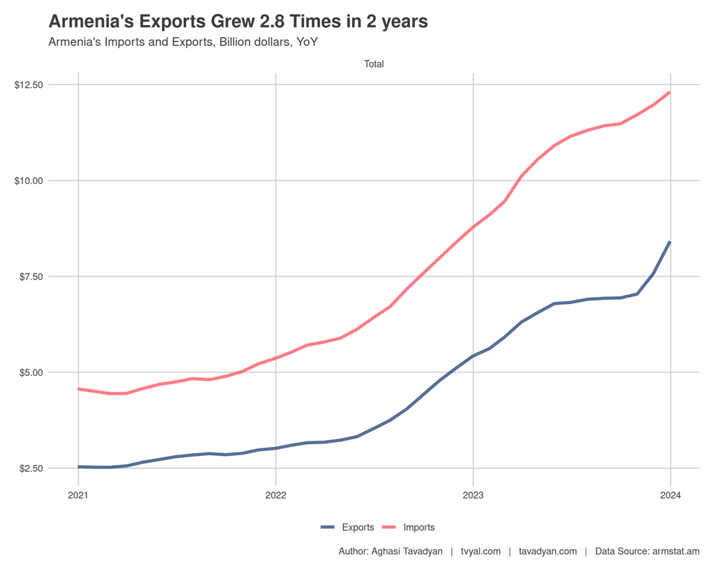

Հատկանշական է, որ 2023 թվականի արտահանման աճի զգալի մասը՝ 31 տոկոս կամ 2,6 միլիարդ դոլար, տեղի է ունեցել վերջին երկու ամիսներին, մասնավորապես՝ նոյեմբերին և դեկտեմբերին։ Այս աճը արտացոլված է գծապատկերում, որտեղ արտահանման կորը, որը մայիս֊սեպտեմբեր ամիսներին արդեն մեծ աճի տենդենց չէր գրանցում, այս ժամանակահատվածում ջարդվում է դեպի վեր: Հուշագրավ է նաև, որ 2023 թվականի դեկտեմբերի դրությամբ Հայաստանը հասել է պատմական իրադարձության՝ արտահանումը այդ ամսվա ընթացքում առաջին անգամ գերազանցել է ներմուծմանը։ Առանց հանկարծահաս աճի 2023 թվականի սեպտեմբերին մեր կողմից կանխատեսվում էր, որ արտահանումը 2023 թվականին կլինի 7.1 մլրդ դոլարի շրջանակներում։

> Արտահանման 75 տոկոսը կազմել է ՌԴ, ԱՄԷ և Հոնկոնգն 2023 թվականին

2023 թվականին Հայաստանի արտահանման 34,4 տոկոսը՝ ավելի քան 1/3-ը, եղել է դեպի Արաբական Միացյալ Էմիրություններ (ԱՄԷ) և Հոնկոնգ։ Ամենամեծ արտահանման ուղղությունը եղել է Ռուսաստանը՝ կազմելով 40,6 տոկոսը։ Այսպես 2023 թվականի արտահանման 75 տոկոսը բաժին է ընկել այս երեք պետություններին։ Նշենք որ 2021 թվականին արտահանման 2.8 տոկոսն էր գրանցվել դեպի ՄԱԷ և Հոնկոնգ (84 մլն դոլար)։ Փաստացի ունենք արտահանման 35 անգամյա աճ 2 տարվա ընթացքում դեպի ՄԱԷ և Հոնկոնգ (տես երկրոդ գծապատկերը)։

Թեև 2023 թվականին ներմուծման և արտահանման ընդհանուր աճը գերազանցել է 40 տոկոսը, իրականությունը ավելի նյուանսավորված է։ Եթե բացառենք Ռուսաստանը, ԱՄԷ-ն և Հոնկոնգը առևտրաշրջանառությունից, ապա դեպի այլ պետություններ 2023 թվականին արտահանումը նվազել է 12,2 տոկոսով, ինչը մտահոգիչ է և նկատելի շեղում է ընդհանուր աճի միտումից։ Վերջին 2 տարիների համար բացառությամբ այս 3 պետությունների արտահանման աճը կազմել է ընդամենը 0,6 տոկոս՝ ընդհանուր 2.8 անգամ աճի համեմատ: Այս փաստը չի վկայում արտահանման կայուն աճի մասին։

**Գծապատկեր 2.** ՀՀ արտահանման և ներմուծման դինամիկան ըստ հիմնական գործընկերների

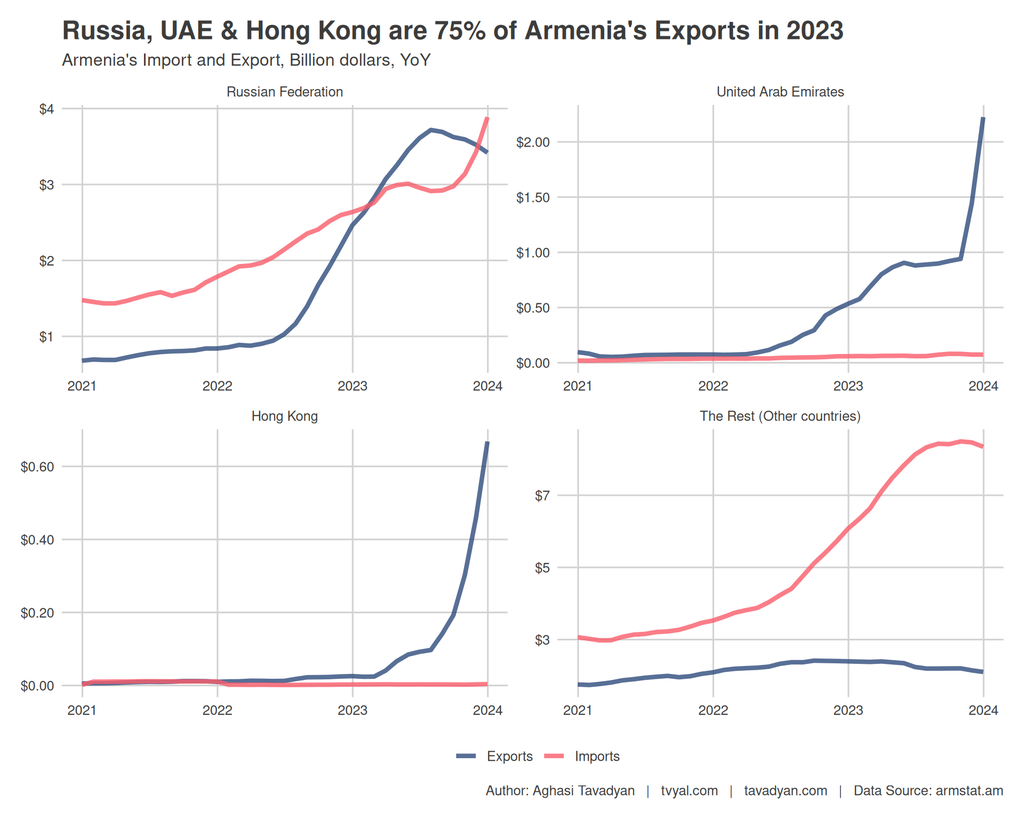

> Արտահանումը նվազել է -12.2 տոկոսով 2023 թվականին, եթե հանենք ՌԴ, ՄԱԷ և Հոնկոնգը

Վերջին երկու տարիների ընթացքում արտահանման աճը գրանցվել է բացառապես դեպի Ռուսաստան, ԱՄԷ և Հոնկոնգ։ Դեպի տվյալ պետություններ գրանցվել է զգալի 6,8 անգամ աճ՝ 0,9 միլիարդ դոլարից (2021) մինչև 6,3 միլիարդ դոլար։

Անդրադառնալով ներմուծմանը, կարևոր է նշել, որ ԱՄԷ-ն և Հոնկոնգը նվազագույն դեր են խաղացել Հայաստանի ներմուծման դինամիկայի մեջ, որը հիմնականում ծագել է Ռուսաստանից։ Ռուսաստանից ներմուծման մի մասը վերաարտահանվել է ԱՄԷ և Հոնկոնգ, որը հանդիսանում է վերջին 2 տարիների արտահանման կառուցվածքային փոփոխության պատճառներից մեկը:

> Հայաստանի արտահանման կառուցվածքի վերաբերյալ կարող եք կարդալ նաև տվյալ նյութում․ [Արտահանման այլընտրանքային ուղղություններ](https://www.tvyal.com/newsletter/2023_11_13)

**Աղյուսակ 1.** Հայաստանի արտահանման դինամիկան

| Exports Partner Regions | 2021 Million USD | 2022 Million USD | 2022 % growth | 2022 % from total | 2023 Million USD | 2023 % growth | 2023 % from total |
| --- | --- | --- | --- | --- | --- | --- | --- |
| EAEU | 882.6 | 2,564.1 | 190.5% | 47.3% | 3,609.3 | 40.8% | 42.9% |
| EU | 656.1 | 772.7 | 17.8% | 14.3% | 709.5 | −8.2% | 8.4% |
| Greater China | 403.1 | 395.1 | −2.0% | 7.3% | 1,093.8 | 176.8% | 13.0% |
| Middle East | 351.4 | 983.2 | 179.8% | 18.1% | 2,538.2 | 158.2% | 30.2% |
| Other countries | 722.8 | 703.9 | −2.6% | 13.0% | 464.3 | −34.0% | 5.5% |
| Total | 3,016.0 | 5,419.1 | 79.7% | 100.0% | 8,415.2 | 55.3% | 100.0% |

Author: Aghasi Tavadyan | tvyal.com | tavadyan.com | Data Source: armstat.am

Նշենք որ մինչ 2021 թիվը կոնյակը եղել է ավանդական հիմնական արտահանումը դեպի Ռուսաստանի Դաշնություն, 2022-23 թվականներին տեղի է ունեցել տեղաշարժ դեպի տեխնոլոգիական առաջադեմ ապրանքներ՝ որպես հիմնական արտահանում: Հատկանշական է, որ առաջատար դիրք են գրավել այնպիսի ապրանքներ, ինչպիսիք են հեռախոսները, ավտոմեքենաները, բժշկական սարքերը և ռադիոսարքավորումները։ Նույն ժամանակահատվածում մեքենաների և սարքավորումների արտահանումը Ռուսաստան աճել է ավելի քան 10 անգամ, մինչդեռ այնպիսի կատեգորիաներ, ինչպիսիք են քիմիական, պլաստմասսա, կերամիկա, ապակի և մետաղներ, աճել են ավելի քան 3 անգամ։ Արտահանման աճին էապես նպաստել է մեքենաների և սարքավորումների վերաարտահանման աճը։ Նշենք որ 2023 թվականի օգոստոսից Վրաստանի և Ռուսաստանի կողմից կիրառվող ավտոմեքենաների վերաարտահանման սահմանափակումները կանգնեցրել են ավտոմեքենաների վերաարդտահանման շարժը դեպի Ռուսաստանի Դաշնություն։ 2024 թվականին ավտոմեքենաների վերաարտահանում չի սպասվում։

> [🚗💨 Հայաստանի “ավտոարտադրության” մահը](https://www.tvyal.com/newsletter/2024/2024_01_19)

Թեև ընդհանուր վիճակագրությունը ցույց է տալիս առևտրաշրջանառության զգալի աճ, մանրակրկիտ ուսումնասիրությունը բացահայտում է տարբեր մտահոգիչ միտումներ։ Երկրորդ գծապատկերից երևում է, որ եթե դիտարկենք այլ պետությունները (բացառությամբ Ռուսաստանի, Էմիրությունների և Հոնկոնգի), ապա 2023 թվականին իհարկե առկա ներմուծման դրական աճ՝ համեմատած 2022 թվականի հետ: Այնուամենայնիվ, ավելի մանրամասն ուսումնասիրությունը բացահայտում է մտահոգիչ միտում՝ 2023 թվականին առկա է դեպի այլ պետությունների ներմուծման աճի բացասական միտում, իսկ արտահանումը այլ ուղղություններով կրճատվել է 12.2 տոկոսով: Այսպես այլ հավասար պայմաններում 2024 թվականին կարելի է ակնկալել որ և՛ ներմուծումը և՛ արտահանումը դեպի այլ պետություններ կարող է կրճատվել։

* Այս վերլուծության բոլոր տվյալները վերցված են պաշտոնական աղբյուրներից, մասնավորապես ԱՎԾ [արտաքին առևտրի տվյալների բազաից](https://armstat.am/am/?nid=717) (ՄԱԷ, Հոնկոնգ)։ Հաշվարկները ամբողջությամբ հասանելի են github-ում, դրանք կարելի է ստուգել այցելելով [github-ի](https://github.com/tavad/tvyal_newsletter/blob/main/2024/) մեր էջը, որտեղ տրված են տվյալները, հաշվարկների և գծապատկերների կոդը։

## English Summary

**📈📉❓ 55.3% Increase in Exports or -12.2% Decline?**

Structural Changes in Armenia’s Trade․

The 2023 Export Study by Partners reveals a substantial 55.3 percent increase in Armenia’s exports, reaching $8.4 billion, with a parallel 40.2 percent surge in imports to $12.3 billion. Notably, a significant portion of the export growth, 31 percent or $2.6 billion, occurred in the last two months of the year, marking a historical moment as Armenia’s exports surpassed imports in December 2023. However, a deeper analysis unveils a nuanced reality—excluding Russia, the UAE, and Hong Kong from the trade cycle results in a concerning 12.2 percent reduction in exports to other countries, challenging the assumption of stable export growth.

The geographical concentration of exports is noteworthy, with 75 percent directed to Russia, the UAE, and Hong Kong in 2023. Despite an overall positive trajectory in trade turnover, the negative trend in exports to other destinations raises concerns, hinting at a potential contraction in both import and export activities to non-core countries in the upcoming year.

## Այս վերլուծությունը առկա է նաև [մեր կայքէջում](https://www.tvyal.com/newsletter/2024/2024_02_16), այս վերլուծության կոդը և տվյալները դրված են նաև [Github-ում](https://github.com/tavad/tvyal_newsletter)։

Եթե հնարավոր է, խնդրում եմ այս նյութը ուղարկել նաև այն մարդկանց, ում այն կարծում եք կարող է հետաքրքրել:

Սպասեք հաջորդ հաղորդագրությանը հաջորդ ուրբաթ օրը:

Հարգանքներով,  
Աղասի Թավադյան  
16.02.2024  
[tvyal.com](https://www.tvyal.com/)  
[tavadyan.com](https://www.tavadyan.com/)

[Was this email forwarded to you? Subscribe here.](https://www.tvyal.com/subscribe)

[Բաժանորդագրվեք](https://www.tvyal.com/subscribe)

**Ուշադրություն. Ձեր էլ.փոստը մեյլիսթի մեջ է, որի միջոցով ես կիսվում եմ շաբաթական նյութեր, որոնք հիմնականում ներկայացնում են Հայաստանի տնտեսությանը: Նյութերը ներառում են գծապատկերներ, [տվյալների բազաներ](https://github.com/tavad/tvyal_newsletter), տեսանյութեր, հոդվածներ, [առցանց վահանակներ](https://www.tvyal.com/projects), տնտեսական գործիքներ, կանխատեսումներ և հաշվետվություններ: Եթե ցանկանում եք չեղարկել բաժանորդագրությունը, խնդրում եմ տեղեկացրեք ինձ, և ես կհեռացնեմ ձեր էլ. փոստը ցուցակից: Գրեք նաև եթե ունեք մենկնաբանություններ:**

**Important! Your email is part of the mailing list where I share weekly materials primarily focused on the Armenian economy. These materials encompass charts, [databases](https://github.com/tavad/tvyal_newsletter), videos, articles, [online dashboards](https://www.tvyal.com/projects), economic tools, forecasts, and reports. If you wish to unsubscribe, please let me know, and I will remove your email from the list. Please share your comments as well․**